# Project 1: Activity Monitoring

Yoselin Arvelaiz

25/9/2020

# Read data

Vamos a leer los datos usando la libreria `readr` y usaremos la función `read_csv()`

```r
library(readr)
activity<-read_csv('activity.csv',col_types=cols(steps = col_double(),
  date = col_date(format = ""),
  interval = col_double()
))
head(activity)
```

```
# A tibble: 6 x 3
  steps date       interval
  <dbl> <date>        <dbl>
1    NA 2012-10-01        0
2    NA 2012-10-01        5
3    NA 2012-10-01       10
4    NA 2012-10-01       15
5    NA 2012-10-01       20
6    NA 2012-10-01       25
```

# First Question: What is mean total number of steps taken per day?

1. Calculate the total number of steps taken per day.

```r
total_steps=sum(activity$steps,na.rm = TRUE)
total_steps
```

```
[1] 570608
```

2. Make a histogram of the total number of steps taken each day

Usaremos la libreria `ggplot2` para crear el histograma del total de pasos por dia. La cantidad de intervalos es `bins=60` y el tamaño es por dia, es decir, `binwidth=1`.

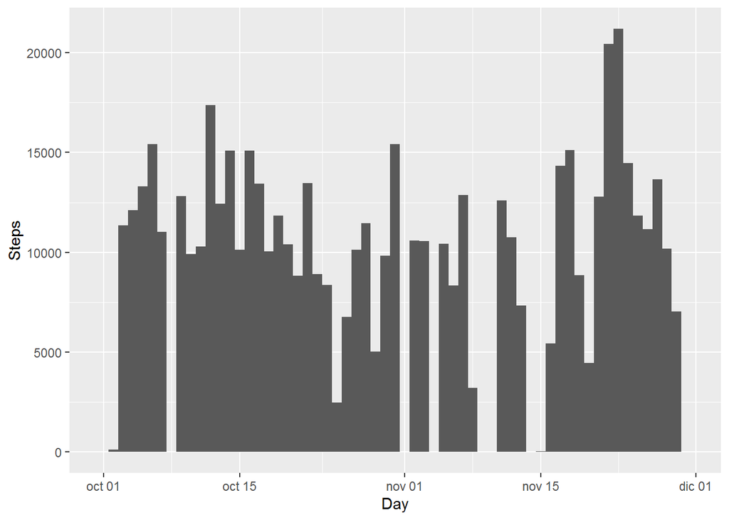

```r
library(ggplot2)
ggplot(data=activity,aes(activity$date))+
  geom_histogram(aes(weight=activity$steps),bins=60,binwidth = 1)+ylab('Steps')+xlab('Day')
```

3. Calculate and report the mean and median of the total number of steps taken per day

```r
media<-mean(activity$steps,na.rm = TRUE)
mediana<-median(activity$steps,na.rm = TRUE)
media
```

```
[1] 37.3826
```

```r
mediana
```

```
[1] 0
```

# Second Question: What is the average daily activity pattern?

1. Make a time series plot (type = “l”) of the 5-minute interval (x-axis) and the average number of steps taken, averaged across all days (y-axis)

En el siguiente código vamos a calcular el promedio de los pasos por dia tomados de acuerdo al intervalo.

```r
filas<-dim(activity)[1]
promedio<-c()
for (i in 1:288){
  z<-c()
  for (j in seq(i,filas,by=288)){
    z<-c(z,activity$steps[j])
  }
  promedio<-c(promedio,mean(z,na.rm = TRUE))
}
head(promedio)
```

```
[1] 1.7169811 0.3396226 0.1320755 0.1509434 0.0754717 2.0943396
```

Para graficar la serie de tiempo, vamos a crear un dataframe con los intervalos y el vector promedio. Usaremos la función `cbind()` para unir los vectores y la función `data.frame()` para convertir los datos en dataframe.

```r
datos<-data.frame(cbind(activity$interval[1:288],promedio))
colnames(datos)<-c('interval','promedio')
head(datos)
```

```
  interval  promedio
1        0 1.7169811
2        5 0.3396226
3       10 0.1320755
4       15 0.1509434
5       20 0.0754717
6       25 2.0943396
```

Usaremos `geom_line()` para graficar la serie de tiempo.

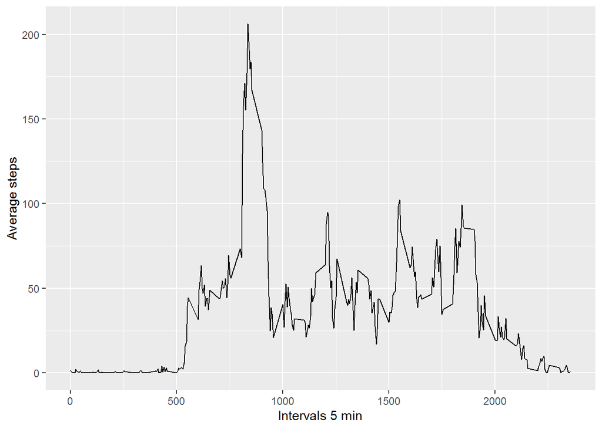

```r
ggplot(data=datos,aes(datos$interval,datos$promedio))+geom_line()+ylab('Average steps')+ xlab('Intervals 5 min')
```

2. Which 5-minute interval, on average across all the days in the dataset, contains the maximum number of steps?

Queremos saber cuál es el intervalo que posee mayor promedio de pasos por dia. Para eso, usaremos la función `which.max()`

```r
max_inter<-datos$interval[which.max(datos$promedio)]
max_inter
```

```
[1] 835
```

El intervalo con mayor pasos en promedio por dia es el intervalo 835

# Third Question: Imputing missing values

1. Calculate and report the total number of missing values in the dataset (i.e. the total number of rows with NAs)

Veamos cuantos valores faltantes hay en los datos activity. Usaremos las funciones `which()` y `is.na()`.

```r
valores_faltantes<-length(which(is.na(activity)))
valores_faltantes
```

```
[1] 2304
```

Hay 2304 valores faltantes (missing values).

2. Devise a strategy for filling in all of the missing values in the dataset. The strategy does not need to be sophisticated. For example, you could use the mean/median for that day, or the mean for that 5-minute interval, etc.

La estrategia que voy a utilzar para rellenar los valores faltantes es el rellenado con la mediana que es 0.

3. Create a new dataset that is equal to the original dataset but with the missing data filled in.

Vamos ahora a rellanar los valores faltantes con la mediana.

```r
filas<-dim(activity)[1]
for (i in 1:filas){
  if (is.na(activity$steps[i])){
    activity$steps[i]<-mediana
  }
}

head(activity)
```

```
# A tibble: 6 x 3
  steps date       interval
  <dbl> <date>        <dbl>
1     0 2012-10-01        0
2     0 2012-10-01        5
3     0 2012-10-01       10
4     0 2012-10-01       15
5     0 2012-10-01       20
6     0 2012-10-01       25
```

4. Make a histogram of the total number of steps taken each day and Calculate and report the mean and median total number of steps taken per day. Do these values differ from the estimates from the first part of the assignment? What is the impact of imputing missing data on the estimates of the total daily number of steps?

Vamos a graficar el histograma ahora con los datos sin valores faltantes.

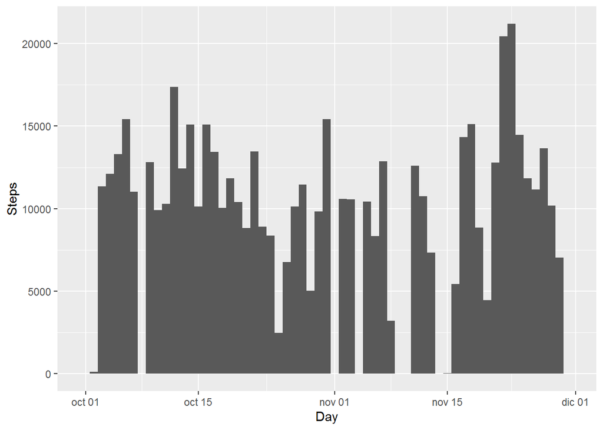

```r
library(ggplot2)
ggplot(data=activity,aes(activity$date))+
  geom_histogram(aes(weight=activity$steps),bins=60,binwidth = 1)+ylab('Steps')+xlab('Day')
```

Ahora calculemos la media y la mediana.

```r
media<-mean(activity$steps)
mediana<-median(activity$steps)
media
```

```
[1] 32.47996
```

```r
mediana
```

```
[1] 0
```

La media y la mediana son respectivamente 32.48 y 0. Podemos observar que la mediana no influyó ya que los valores que faltaban fueron rellenados por la mediana, pero la media bajo un poco de 37 a 32. Los valores faltantes siempre influyen en los datos y cuando se rellenan se tiene que conocer muy bien los datos para armar una buena estrategia que sume importante información.

# Last Question: Are there differences in activity patterns between weekdays and weekends?

1. Create a new factor variable in the dataset with two levels – “weekday” and “weekend” indicating whether a given date is a weekday or weekend day.

```r
for (i in 1:17568){
  if (weekdays(activity$date[i])=='sabado' | weekdays(activity$date[i])=='domingo'){
    activity$week[i]<-'weekend'
  }
  else{
    activity$week[i]<-'weekdays'
  }
}

head(activity)
```

```
# A tibble: 6 x 4
  steps date       interval week
  <dbl> <date>        <dbl> <chr>
1     0 2012-10-01        0 weekdays
2     0 2012-10-01        5 weekdays
3     0 2012-10-01       10 weekdays
4     0 2012-10-01       15 weekdays
5     0 2012-10-01       20 weekdays
6     0 2012-10-01       25 weekdays
```

2. Make a panel plot containing a time series plot (type = “l”) of the 5-minute interval (x-axis) and the average number of steps taken, averaged across all weekday days or weekend days (y-axis).

En esta parte calcularemos el promedio de pasos por fin de semana y las semanas laborales de acuerdo a los intervalos.

```r
filas<-dim(activity)[1]

#Weekdays
prom_weekdays<-c()
for (i in 1:288){
  z<-c()
  for (j in seq(i,filas,by=288)){
    if (activity$week[j]=='weekdays'){
        z<-c(z,activity$steps[j])
    }
  }
  prom_weekdays<-c(prom_weekdays,mean(z,na.rm = TRUE))
}
head(prom_weekdays)
```

```
[1] 1.7169811 0.3396226 0.1320755 0.1509434 0.0754717 1.1132075
```

```r
#Weekend

prom_weekend<-c()
for (i in 1:288){
  z<-c()
  for (j in seq(i,filas,by=288)){
    if (activity$week[j]=='weekend'){
        z<-c(z,activity$steps[j])
    }
  }
  prom_weekend<-c(prom_weekend,mean(z,na.rm = TRUE))
}

head(prom_weekend)
```

```
[1] 0.0 0.0 0.0 0.0 0.0 6.5
```

Creamos los datos con la información de arriba.

```r
datos1<-data.frame(cbind(activity$interval[1:288],prom_weekdays))
colnames(datos1)<-c('interval','weekdays')
head(datos1)
```

```
  interval  weekdays
1        0 1.7169811
2        5 0.3396226
3       10 0.1320755
4       15 0.1509434
5       20 0.0754717
6       25 1.1132075
```

```r
datos2<-data.frame(cbind(activity$interval[1:288],prom_weekend))
colnames(datos2)<-c('interval','weekend')
head(datos2)
```

```
  interval weekend
1        0     0.0
2        5     0.0
3       10     0.0
4       15     0.0
5       20     0.0
6       25     6.5
```

[figure not shown]

```r
library(ggplot2)
library(gridExtra)

weekday<-ggplot(data=datos1,aes(datos1$interval,datos1$weekdays))+geom_line()+ylab('average steps for weekdays')+ xlab('Intervals 5 min')

weekend<-ggplot(data=datos1,aes(datos1$interval,datos1$weekdays))+geom_line()+ylab('average steps for weekdays')+ xlab('Intervals 5 min')

grid.arrange(weekday, weekend, ncol = 2, widths = c(6, 6))
```